# Predict Number of Rings Produced By Abalone

Author

Huiting Wu

```r
# load packages
library(tidyverse)
library(rpart)
library(randomForest)
library(vip)
```

```r
library(AppliedPredictiveModeling)
data("abalone")
```

# Exporatory Data Analysis

```r
summary(abalone)
```

```
 Type      LongestShell      Diameter          Height        WholeWeight
 F:1307   Min.   :0.075   Min.   :0.0550   Min.   :0.0000   Min.   :0.0020
 I:1342   1st Qu.:0.450   1st Qu.:0.3500   1st Qu.:0.1150   1st Qu.:0.4415
 M:1528   Median :0.545   Median :0.4250   Median :0.1400   Median :0.7995
          Mean   :0.524   Mean   :0.4079   Mean   :0.1395   Mean   :0.8287
          3rd Qu.:0.615   3rd Qu.:0.4800   3rd Qu.:0.1650   3rd Qu.:1.1530
          Max.   :0.815   Max.   :0.6500   Max.   :1.1300   Max.   :2.8255
 ShuckedWeight    VisceraWeight     ShellWeight         Rings
 Min.   :0.0010   Min.   :0.0005   Min.   :0.0015   Min.   : 1.000
 1st Qu.:0.1860   1st Qu.:0.0935   1st Qu.:0.1300   1st Qu.: 8.000
 Median :0.3360   Median :0.1710   Median :0.2340   Median : 9.000
 Mean   :0.3594   Mean   :0.1806   Mean   :0.2388   Mean   : 9.934
 3rd Qu.:0.5020   3rd Qu.:0.2530   3rd Qu.:0.3290   3rd Qu.:11.000
 Max.   :1.4880   Max.   :0.7600   Max.   :1.0050   Max.   :29.000
```

- There are 1307 of female type, 1342 infant type, and 1528 male type. The average rings of abalone is around 10. The minimum rings of abalone in the data is 1 and the maximum rings of abalone is 29.

```r
str(abalone)
```

```
'data.frame':   4177 obs. of  9 variables:
 $ Type         : Factor w/ 3 levels "F","I","M": 3 3 1 3 2 2 1 1 3 1 ...
 $ LongestShell : num  0.455 0.35 0.53 0.44 0.33 0.425 0.53 0.545 0.475 0.55 ...
 $ Diameter     : num  0.365 0.265 0.42 0.365 0.255 0.3 0.415 0.425 0.37 0.44 ...
 $ Height       : num  0.095 0.09 0.135 0.125 0.08 0.095 0.15 0.125 0.125 0.15 ...
 $ WholeWeight  : num  0.514 0.226 0.677 0.516 0.205 ...
 $ ShuckedWeight: num  0.2245 0.0995 0.2565 0.2155 0.0895 ...
 $ VisceraWeight: num  0.101 0.0485 0.1415 0.114 0.0395 ...
 $ ShellWeight  : num  0.15 0.07 0.21 0.155 0.055 0.12 0.33 0.26 0.165 0.32 ...
 $ Rings        : int  15 7 9 10 7 8 20 16 9 19 ...
```

- The variable Type is a factor. The response variable, Rings, is integers and other predictors are numerical.

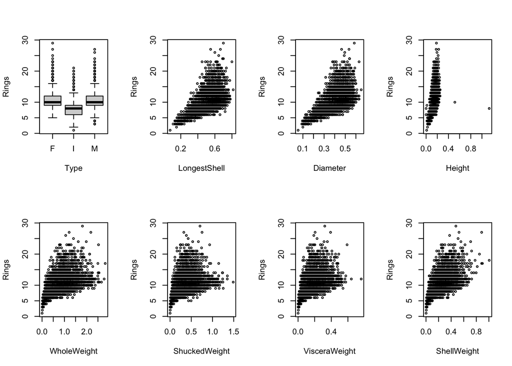

```r
par(mfrow = c(2, 4))
plot(Rings~., data = abalone, cex = 0.5)
```

# Cross-Validation

```r
set.seed(452)
n <- nrow(abalone)
train_index <- sample(1:n, round(0.7*n))
train <- abalone[train_index, ]
test <- abalone[-train_index, ]
```

```r
f1 <- lm(Rings ~., data = train)
summary(f1)
```

```
Call:
lm(formula = Rings ~ ., data = train)

Residuals:
    Min      1Q  Median      3Q     Max
-8.6858 -1.3227 -0.3722  0.8920 13.7310

Coefficients:
              Estimate Std. Error t value Pr(>|t|)
(Intercept)     4.0057     0.3528  11.354  < 2e-16 ***
TypeI          -0.7514     0.1245  -6.037 1.77e-09 ***
TypeM           0.1260     0.1017   1.239    0.216
LongestShell   -0.4432     2.1603  -0.205    0.837
Diameter       11.0918     2.6592   4.171 3.12e-05 ***
Height          9.0459     1.6771   5.394 7.45e-08 ***
WholeWeight    10.0053     0.8634  11.588  < 2e-16 ***
ShuckedWeight -21.1402     0.9809 -21.552  < 2e-16 ***
VisceraWeight -10.5316     1.5594  -6.754 1.73e-11 ***
ShellWeight     7.6360     1.3460   5.673 1.54e-08 ***
---
Signif. codes:  0 '***' 0.001 '**' 0.01 '*' 0.05 '.' 0.1 ' ' 1

Residual standard error: 2.233 on 2914 degrees of freedom
Multiple R-squared:  0.5242,    Adjusted R-squared:  0.5227
F-statistic: 356.7 on 9 and 2914 DF,  p-value: < 2.2e-16
```

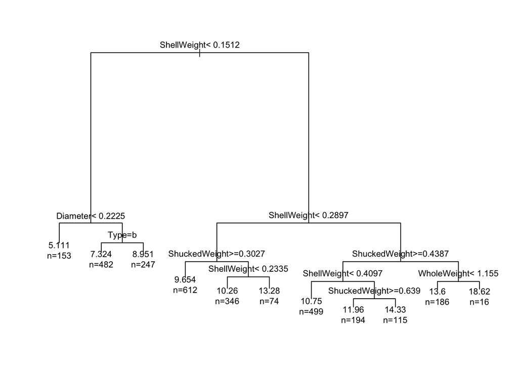

```r
f2 <- rpart(Rings ~., data = train, method = "anova")
par(cex = 0.7, xpd = NA)
plot(f2)
text(f2, use.n = TRUE)
```

```r
f3 <- randomForest(Rings ~., data = train, importance = TRUE)
```

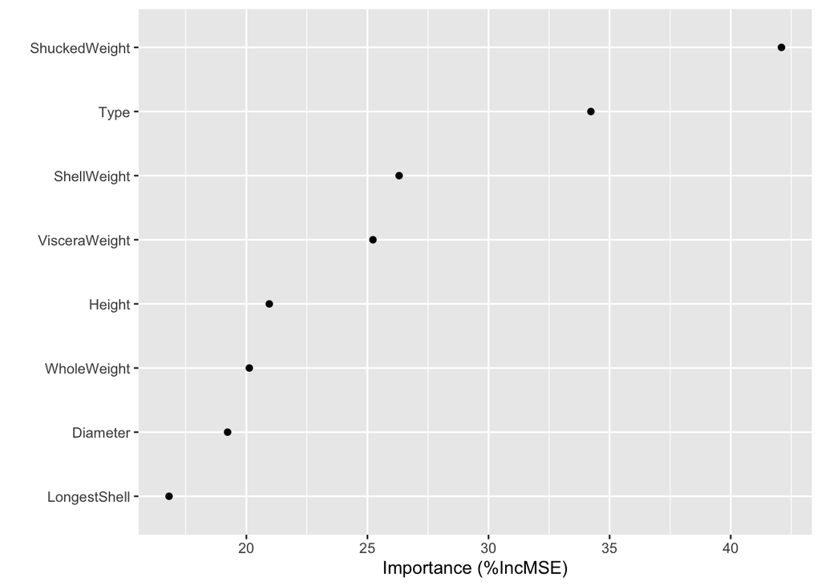

```r
vip(f3, num_features = 10, geom = "point", include_type = TRUE)
```

```r
MLR_pred <- predict(f1, newdata = test)
Regression_pred <- predict(f2, newdata = test)
RF_pred <- predict(f3, newdata = test)
```

```r
actual_pred_table <- data.frame(
  Actual = test$Rings,
  MLR_Prediction = MLR_pred,
  Regression_Prediction = Regression_pred,
  RandomForest_Prediction = RF_pred
)
```

```r
RMSE <- function(y, y_hat) {
sqrt(mean((y - y_hat)^2))
}
```

```r
RMSE(actual_pred_table$Actual, actual_pred_table$MLR_Prediction)
```

```
[1] 2.107246
```

```r
RMSE(actual_pred_table$Actual, actual_pred_table$Regression_Prediction)
```

```
[1] 2.368938
```

```r
rf_RMSE <- RMSE(actual_pred_table$Actual, actual_pred_table$RandomForest_Prediction)
rf_RMSE
```

```
[1] 2.071234
```

```r
cor(actual_pred_table$Actual, actual_pred_table$MLR_Prediction)^2
```

```
[1] 0.5700077
```

```r
cor(actual_pred_table$Actual, actual_pred_table$Regression_Prediction)^2
```

```
[1] 0.4564792
```

```r
r2 <- cor(actual_pred_table$Actual, actual_pred_table$RandomForest_Prediction)^2
r2
```

```
[1] 0.5835076
```

[output not shown]

- According to RMSE, the random forest model has the best predictive performance.
- According to the $R^2$, it is also the random forest model has the best predictive performance.
- Overall, the random forest model has the best performance and the regression tree has the worst predictive performance.

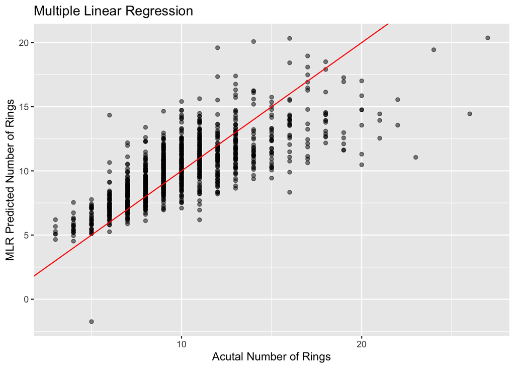

```r
ggplot(actual_pred_table, aes(x = Actual, y = MLR_Prediction)) +
  geom_point(alpha = 0.5) +
  geom_abline(intercept = 0, slope = 1, color = "red") +
  xlab("Acutal Number of Rings") +
  ylab("MLR Predicted Number of Rings") +
  ggtitle("Multiple Linear Regression")
```

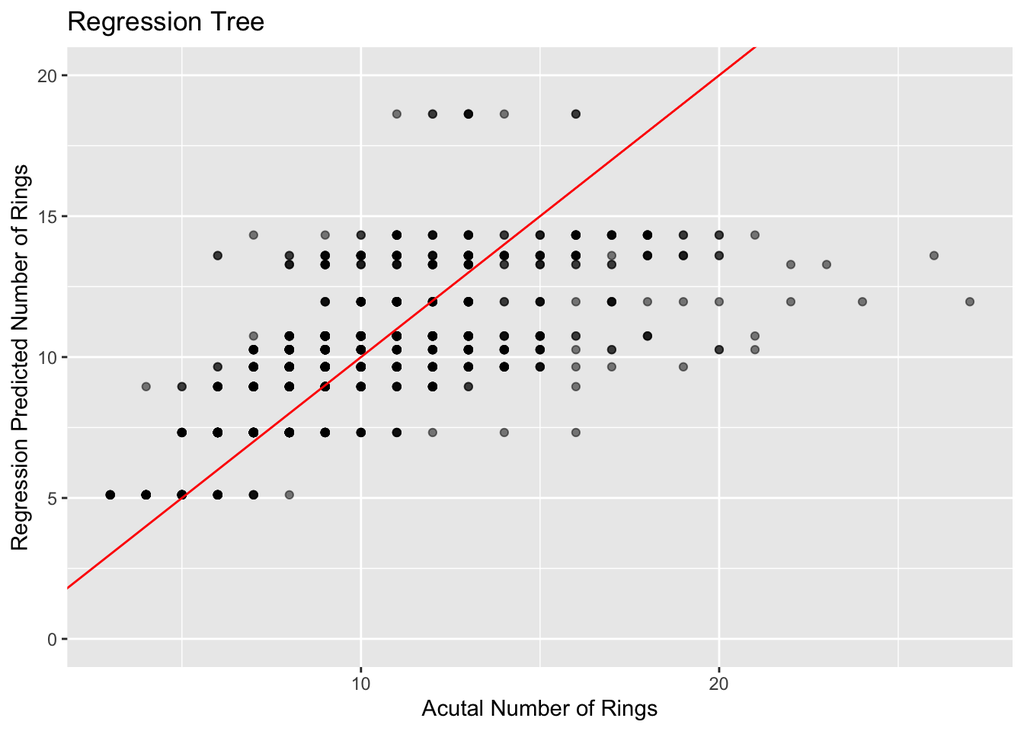

```r
ggplot(actual_pred_table, aes(x = Actual, y = Regression_Prediction)) +
  geom_point(alpha = 0.5) +
  geom_abline(intercept = 0, slope = 1, color = "red") +
  xlab("Acutal Number of Rings") +
  ylab("Regression Predicted Number of Rings") +
  ggtitle("Regression Tree") +
  ylim(0, 20)
```

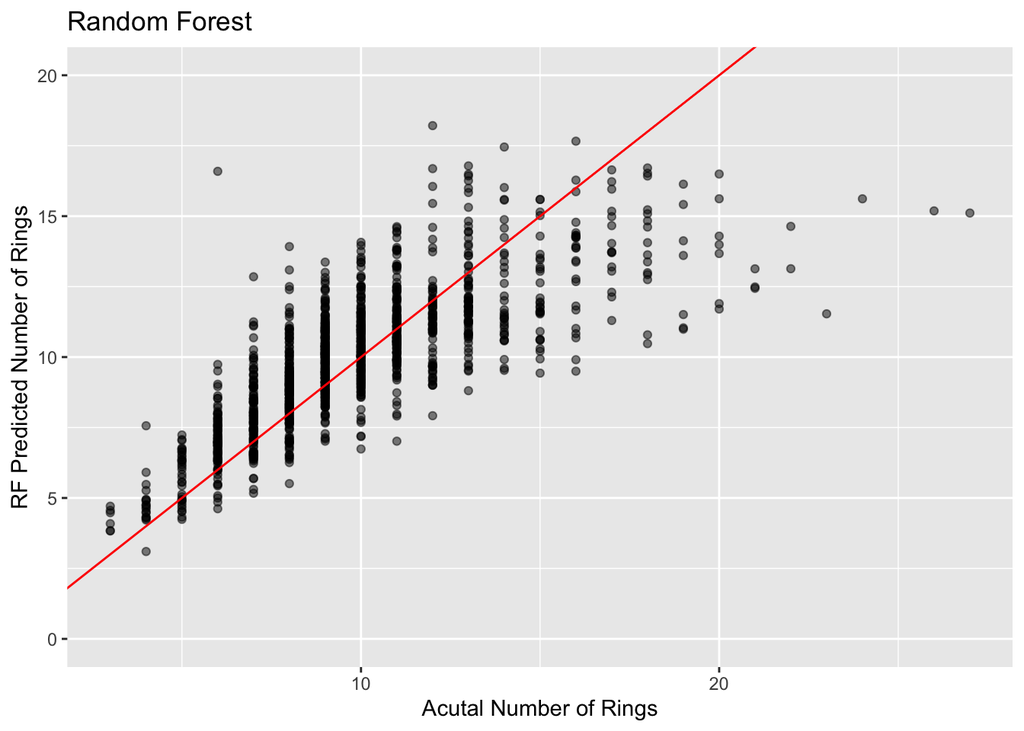

```r
ggplot(actual_pred_table, aes(x = Actual, y = RandomForest_Prediction)) +
  geom_point(alpha = 0.5) +
  geom_abline(intercept = 0, slope = 1, color = "red") +
  xlab("Acutal Number of Rings") +
  ylab("RF Predicted Number of Rings") +
  ggtitle("Random Forest") +
  ylim(0, 20)
```

- The regression tree might overfit the training data so that the patterns in the plot of the predicted versus actual values for the regression tree model look different than the random forest and linear regression models.